# Flow Cytometry Analysis - June 9, 2026

Tanishka Joshi

6/11/2026

## Overview

This notebook analyzes flow cytometry data collected on June 9, 2026 on the Cytek Aurora. Samples were run in glutamine-limited media to look for CNV (copy number variation) of mCitrine.

**Samples analyzed (TJ = Tanishka Joshi):**

| Sample Name | Strain | Expected Copy Number |
| --- | --- | --- |
| Students_June9-TJ2807 | DGY2807 | 0 copy control |
| Students_June9-TJ3283 | DGY3283 | 0 copy control |
| Students_June9-TJ3961 | DGY3961 | CNV reporter / experimental |
| Students_June9-3960 | DGY3960 | CNV reporter / experimental |

mCitrine fluorescence was measured via the **B2-A channel** (ex 516 nm / em 529 nm).

## Install & Load Packages

```r
# Run once if packages are not yet installed
if (!requireNamespace("BiocManager", quietly = TRUE)) install.packages("BiocManager")
BiocManager::install(c("cytolib", "flowCore", "flowWorkspace", "openCyto"))

if (!requireNamespace("devtools", quietly = TRUE)) install.packages("devtools")
devtools::install_github("DillonHammill/CytoExploreR")

install.packages(c("tidyverse", "ggridges", "RColorBrewer"))
```

```r
# Only needed for Part 1 (FCS workflow) — requires Bioconductor packages
library(CytoExploreR)
library(flowCore)
library(flowWorkspace)
```

```r
# Packages for Parts 2 & 3 (CSV analysis and plots)
library(tidyverse)
library(ggridges)
library(ggrepel)
library(RColorBrewer)
```

## Part 1: FCS File Workflow (CytoExploreR)

This section walks through loading the FCS files and applying the gating template. **Note:** `cyto_gate_draw()` requires an interactive R session (not inside a notebook chunk). Run those steps in the Console, then use `cyto_gatingTemplate_apply()` here.

### Set working directory and version name

```r
# Set this to the folder containing your FCS files
knitr::opts_knit$set(root.dir = "C:/Users/tanis/Gresham Lab/summerIntensive2026/data/FCSfiles6-11-2026")
```

```r
version_name <- "TJ_june9_2026_v1"
fcs_path <- "C:/Users/tanis/Gresham Lab/summerIntensive2026/data/FCSfiles6-11-2026"
```

### STEP 1: Load FCS files as a gating set

```r
# INSTRUCTIONS: An editable markers sheet will pop up in the Viewer pane.
# Type "B2-A" in the marker column for the B2-A channel, then click Save & Close.
my_gating_set <- cyto_setup(path = fcs_path, restrict = TRUE, select = "fcs")
```

### STEP 2: Add sample metadata

```r
# Rename autogenerated files (only do once)
file.rename(dir(pattern = "Experiment-Details.csv"), paste0(version_name, "-Experiment-Details.csv"))
file.rename(dir(pattern = "Experiment-Markers.csv"),  paste0(version_name, "-Experiment-Markers.csv"))

# Build a metadata table for your 4 samples
sample_metadata <- tibble(
  name = c(
    "Students_June9-TJ2807",
    "Students_June9-TJ3283",
    "Students_June9-TJ3961",
    "Students_June9-3960"
  ),
  Strain      = c("DGY2807", "DGY3283", "DGY3961", "DGY3960"),
  Description = c("0 copy control", "0 copy control", "CNV reporter", "CNV reporter"),
  `mCitrine copy number` = c("zero copy", "zero copy", "experimental", "experimental")
)

exp_details  <- read_csv(list.files(pattern = "Experiment-Details.csv"))
experiment_details <- left_join(exp_details, sample_metadata) %>%
  write_csv(paste0(version_name, "-Experiment-Details.csv"))

# Attach metadata to gating set
for (i in seq_along(names(experiment_details))) {
  flowWorkspace::pData(my_gating_set)[names(experiment_details[i])] <- experiment_details[i]
}

cyto_details(my_gating_set)
```

### STEP 3: Transform data

```r
GFP_trans <- cyto_transformer_logicle(
  my_gating_set,
  channels   = "B2-A",
  widthBasis = -10
)

FSC_SSC_trans <- cyto_transformer_log(
  my_gating_set,
  channels = c("FSC-A", "FSC-H", "SSC-A", "SSC-H")
)

combined_trans         <- cyto_transformer_combine(GFP_trans, FSC_SSC_trans)
transformed_gating_set <- cyto_transform(my_gating_set, trans = combined_trans)
```

### STEP 3b: Explore transformed data

```r
cyto_plot_explore(transformed_gating_set,
                  channels_x  = "FSC-A",
                  channels_y  = "B2-A",
                  axes_limits = "data")
```

### STEP 3c: Draw gates (run in Console, not in notebook)

```r
# Gate 1: Cells (remove debris)
cyto_gate_draw(transformed_gating_set,
               parent       = "root",
               alias        = "Cells",
               channels     = c("FSC-A", "SSC-A"),
               axes_limits  = "data",
               gatingTemplate = paste0("cytek_gating_", version_name, ".csv"))

# Gate 2: Singlets
cyto_gate_draw(transformed_gating_set,
               parent       = "Cells",
               alias        = "FSC_Singlets",
               channels     = c("FSC-A", "FSC-H"),
               axes_limits  = "data",
               gatingTemplate = paste0("cytek_gating_", version_name, ".csv"))

# Gate 3: mCitrine copy number populations
# Extract zero-copy controls to use as overlay reference
zero_ctrl <- cyto_extract(transformed_gating_set, "FSC_Singlets")[
  grep("TJ2807|TJ3283", names(cyto_extract(transformed_gating_set, "FSC_Singlets")))
]

cyto_gate_draw(transformed_gating_set,
               point_col    = c("gray", "green", "blue"),
               parent       = "FSC_Singlets",
               overlay      = zero_ctrl,
               alias        = c("zero_copy", "one_copy", "two_or_more_copy"),
               channels     = c("FSC-A", "B2-A"),
               axes_limits  = "data",
               gatingTemplate = paste0("cytek_gating_", version_name, ".csv"))
```

### STEP 3d: Apply existing gating template (if already made)

```r
cyto_gatingTemplate_apply(
  transformed_gating_set,
  gatingTemplate = paste0("cytek_gating_", version_name, ".csv")
)
```

### STEP 4 (FCS path): Extract raw single-cell data

```r
timepoint_raw_list <- cyto_extract(
  transformed_gating_set,
  parent   = "FSC_Singlets",
  raw      = TRUE,
  channels = c("FSC-A", "B2-A")
)

sc_distr_fcs <- map_df(timepoint_raw_list, ~as.data.frame(.x), .id = "name") %>%
  left_join(experiment_details) %>%
  mutate(B2A_FSC = `B2-A` / `FSC-A`) %>%
  write_csv(paste0(version_name, "_SingleCellDistributions.csv"))
```

## Part 2: Analysis from Pre-Computed Statistics (CSV)

The gating was performed in SpectroFlo / CytoExploreR and statistics were exported. We load that CSV here for all downstream analysis and plots.

### Load and reshape the statistics CSV

```r
raw_stats <- read_csv(
  "C:/Users/tanis/Downloads/June9_Scer_students.CSV",
  show_col_types = FALSE
)

# The first column is the sample name (unnamed in the CSV)
colnames(raw_stats)[1] <- "sample_name"

# Tidy: pull out the columns we need for the key gates
# Gates available: Cells, FSC_Singlets, mCitrine, FSC_S_1copy, FSC_S_2copy, FSC_S_0copy
stats_tidy <- raw_stats %>%
  select(
    sample_name,
    # Cells gate
    Cells_Count        = `Cells Count`,
    Cells_pct          = `Cells % Total`,
    # FSC Singlets gate
    Singlets_Count     = `FSC_Singlets Count`,
    Singlets_pct       = `FSC_Singlets % Total`,
    # mCitrine gate (positive cells)
    mCit_Count         = `mCitrine Count`,
    mCit_pct_parent    = `mCitrine % Parent`,
    # Copy number gates (parent = FSC_Singlets)
    copy0_Count        = `FSC_S_0copy Count`,
    copy0_pct          = `FSC_S_0copy % Parent`,
    copy1_Count        = `FSC_S_1copy Count`,
    copy1_pct          = `FSC_S_1copy % Parent`,
    copy2_Count        = `FSC_S_2copy Count`,
    copy2_pct          = `FSC_S_2copy % Parent`,
    # Median B2-A fluorescence
    Median_B2A_singlets = `FSC_Singlets Median B2-A`
  )

# Extract strain number and student initials from sample name
stats_tidy <- stats_tidy %>%
  mutate(
    strain    = str_extract(sample_name, "\\d{4}$"),
    student   = case_when(
      str_detect(sample_name, "TJ")  ~ "TJ",
      str_detect(sample_name, "LCS") ~ "LCS",
      str_detect(sample_name, "AG")  ~ "AG",
      TRUE                           ~ "Other"
    ),
    # Label zero-copy controls (low B2-A strains: 2807, 3283)
    copy_class = case_when(
      strain %in% c("2807", "3283") ~ "Zero-copy control",
      TRUE                          ~ "mCitrine strain"
    )
  )

stats_tidy %>%
  select(sample_name, strain, student, Cells_Count, Singlets_Count, copy0_pct, copy1_pct, copy2_pct) %>%
  knitr::kable(digits = 2, caption = "Gate statistics summary")
```

Gate statistics summary

| sample_name | strain | student | Cells_Count | Singlets_Count | copy0_pct | copy1_pct | copy2_pct |
| --- | --- | --- | --- | --- | --- | --- | --- |
| Students_June9-3959 | 3959 | Other | 18591 | 11702 | 0.00 | 0.03 | 99.69 |
| Students_June9-3958 | 3958 | Other | 18953 | 10604 | 0.01 | 0.09 | 98.92 |
| Students_June9-3283 | 3283 | Other | 18763 | 11259 | 94.00 | 0.00 | 0.01 |
| Students_June9-2807 | 2807 | Other | 18632 | 11636 | 94.61 | 0.00 | 0.00 |
| Students_June9-3960 | 3960 | Other | 19150 | 12689 | 0.02 | 0.06 | 99.51 |
| Students_June9-TJ2807 | 2807 | TJ | 19333 | 12694 | 93.74 | 0.00 | 0.00 |
| Students_June9-TJ3961 | 3961 | TJ | 19240 | 11670 | 0.18 | 0.11 | 99.43 |
| Students_June9-TJ3283 | 3283 | TJ | 18866 | 10955 | 94.11 | 0.00 | 0.01 |
| Students_June9-2807LCS | NA | LCS | 19317 | 14092 | 92.80 | 0.01 | 0.00 |
| Students_June9-3283LCS | NA | LCS | 18568 | 11177 | 93.94 | 0.11 | 0.00 |
| Students_June9-3957LCS | NA | LCS | 19293 | 11298 | 0.04 | 0.28 | 98.98 |
| Students_June9-3956LCS | NA | LCS | 18831 | 10608 | 0.00 | 0.14 | 65.95 |
| Students_June9-3283AG | NA | AG | 18201 | 9851 | 95.45 | 0.06 | 0.00 |
| Students_June9-3955AG | NA | AG | 19393 | 12960 | 0.01 | 0.11 | 99.64 |
| Students_June9-3954AG | NA | AG | 12701 | 7509 | 38.27 | 0.17 | 42.75 |
| Students_June9-2807AG | NA | AG | 19034 | 12392 | 93.34 | 0.01 | 0.02 |

### Filter to TJ samples only

```r
tj_stats <- stats_tidy %>%
  filter(student == "TJ") %>%
  mutate(
    Description = case_when(
      strain %in% c("2807", "3283") ~ "0 copy control",
      TRUE                          ~ "CNV reporter"
    ),
    strain_label = paste0("DGY", strain)
  )

tj_stats %>%
  select(strain_label, Description, Singlets_Count, copy0_pct, copy1_pct, copy2_pct, Median_B2A_singlets) %>%
  knitr::kable(digits = 2, caption = "TJ sample gate statistics")
```

TJ sample gate statistics

| strain_label | Description | Singlets_Count | copy0_pct | copy1_pct | copy2_pct | Median_B2A_singlets |
| --- | --- | --- | --- | --- | --- | --- |
| DGY2807 | 0 copy control | 12694 | 93.74 | 0.00 | 0.00 | 715.86 |
| DGY3961 | CNV reporter | 11670 | 0.18 | 0.11 | 99.43 | 82028.81 |
| DGY3283 | 0 copy control | 10955 | 94.11 | 0.00 | 0.01 | 725.91 |

### Check cell counts (>70,000 singlets per sample?)

```r
tj_stats %>%
  select(strain_label, Description, Singlets_Count) %>%
  mutate(QC_pass = Singlets_Count >= 70000) %>%
  knitr::kable(caption = "QC: singlet counts per sample")
```

QC: singlet counts per sample

| strain_label | Description | Singlets_Count | QC_pass |
| --- | --- | --- | --- |
| DGY2807 | 0 copy control | 12694 | FALSE |
| DGY3961 | CNV reporter | 11670 | FALSE |
| DGY3283 | 0 copy control | 10955 | FALSE |

## Part 3: Visualizations

### Plot 1: Bar chart of copy-number gate frequencies (TJ samples)

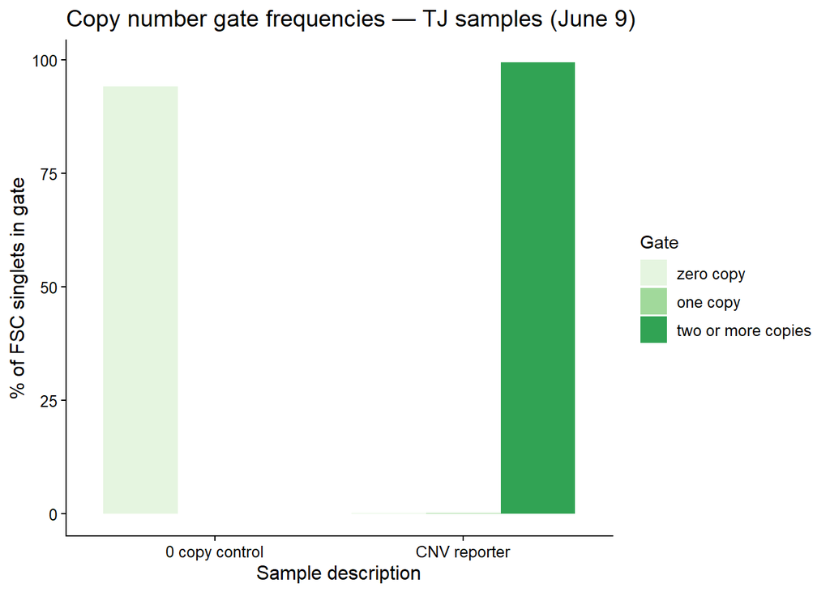

```r
# Reshape to long format for plotting
copy_long_tj <- tj_stats %>%
  select(strain_label, Description, copy0_pct, copy1_pct, copy2_pct) %>%
  pivot_longer(
    cols      = c(copy0_pct, copy1_pct, copy2_pct),
    names_to  = "Gate",
    values_to = "Frequency"
  ) %>%
  mutate(
    Gate = recode(Gate,
      copy0_pct = "zero copy",
      copy1_pct = "one copy",
      copy2_pct = "two or more copies"
    ),
    Gate        = fct_relevel(Gate, "zero copy", "one copy", "two or more copies"),
    Description = fct_relevel(Description, "0 copy control", "CNV reporter")
  )

ggplot(copy_long_tj, aes(x = Description, y = Frequency, fill = Gate)) +
  geom_bar(position = "dodge", stat = "identity") +
  scale_fill_manual(values = RColorBrewer::brewer.pal(3, "Greens")) +
  ylab("% of FSC singlets in gate") +
  xlab("Sample description") +
  ggtitle("Copy number gate frequencies — TJ samples (June 9)") +
  theme_classic() +
  theme(
    text         = element_text(size = 12),
    axis.text.x  = element_text(color = "black"),
    axis.text.y  = element_text(color = "black"),
    legend.title = element_text(size = 11)
  )
```

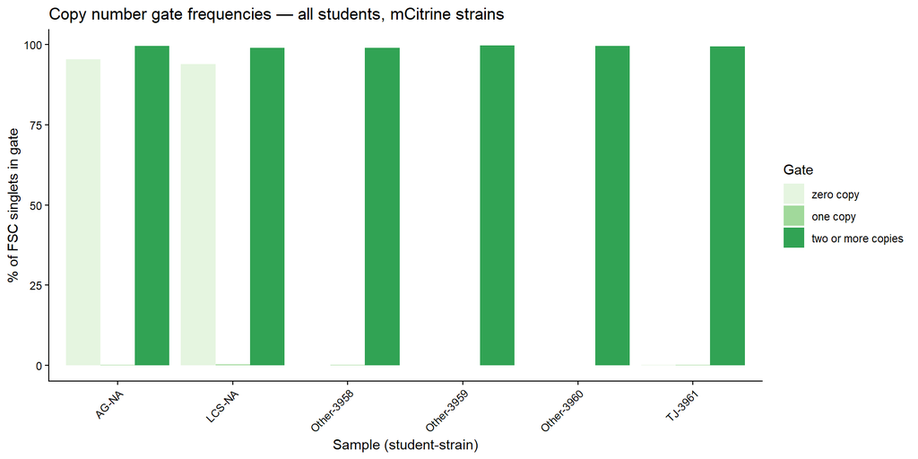

```r
copy_long_all <- stats_tidy %>%
  filter(copy_class == "mCitrine strain") %>%
  select(sample_name, student, strain, copy0_pct, copy1_pct, copy2_pct) %>%
  pivot_longer(
    cols      = c(copy0_pct, copy1_pct, copy2_pct),
    names_to  = "Gate",
    values_to = "Frequency"
  ) %>%
  mutate(
    Gate = recode(Gate,
      copy0_pct = "zero copy",
      copy1_pct = "one copy",
      copy2_pct = "two or more copies"
    ),
    Gate         = fct_relevel(Gate, "zero copy", "one copy", "two or more copies"),
    sample_label = paste0(student, "-", strain)
  )

ggplot(copy_long_all, aes(x = sample_label, y = Frequency, fill = Gate)) +
  geom_bar(position = "dodge", stat = "identity") +
  scale_fill_manual(values = RColorBrewer::brewer.pal(3, "Greens")) +
  ylab("% of FSC singlets in gate") +
  xlab("Sample (student-strain)") +
  ggtitle("Copy number gate frequencies — all students, mCitrine strains") +
  theme_classic() +
  theme(
    text         = element_text(size = 11),
    axis.text.x  = element_text(angle = 45, hjust = 1, color = "black"),
    axis.text.y  = element_text(color = "black")
  )
```

### Plot 3: Median B2-A fluorescence per sample

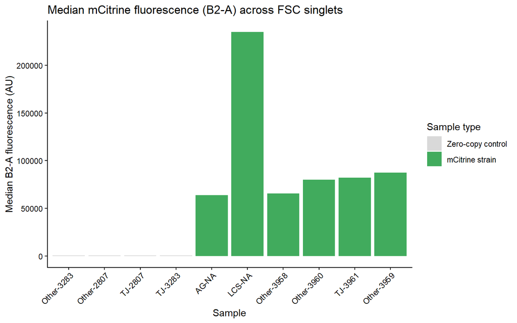

```r
stats_tidy %>%
  mutate(
    sample_label = paste0(student, "-", strain),
    copy_class   = fct_relevel(copy_class, "Zero-copy control", "mCitrine strain")
  ) %>%
  ggplot(aes(x = reorder(sample_label, Median_B2A_singlets),
             y = Median_B2A_singlets,
             fill = copy_class)) +
  geom_col() +
  scale_fill_manual(values = c("Zero-copy control" = "#d9d9d9", "mCitrine strain" = "#41ab5d"),
                    name   = "Sample type") +
  ylab("Median B2-A fluorescence (AU)") +
  xlab("Sample") +
  ggtitle("Median mCitrine fluorescence (B2-A) across FSC singlets") +
  theme_classic() +
  theme(
    axis.text.x = element_text(angle = 45, hjust = 1, color = "black", size = 9),
    axis.text.y = element_text(color = "black")
  )
```

### Plot 4: % cells in mCitrine gate vs. median fluorescence (scatter)

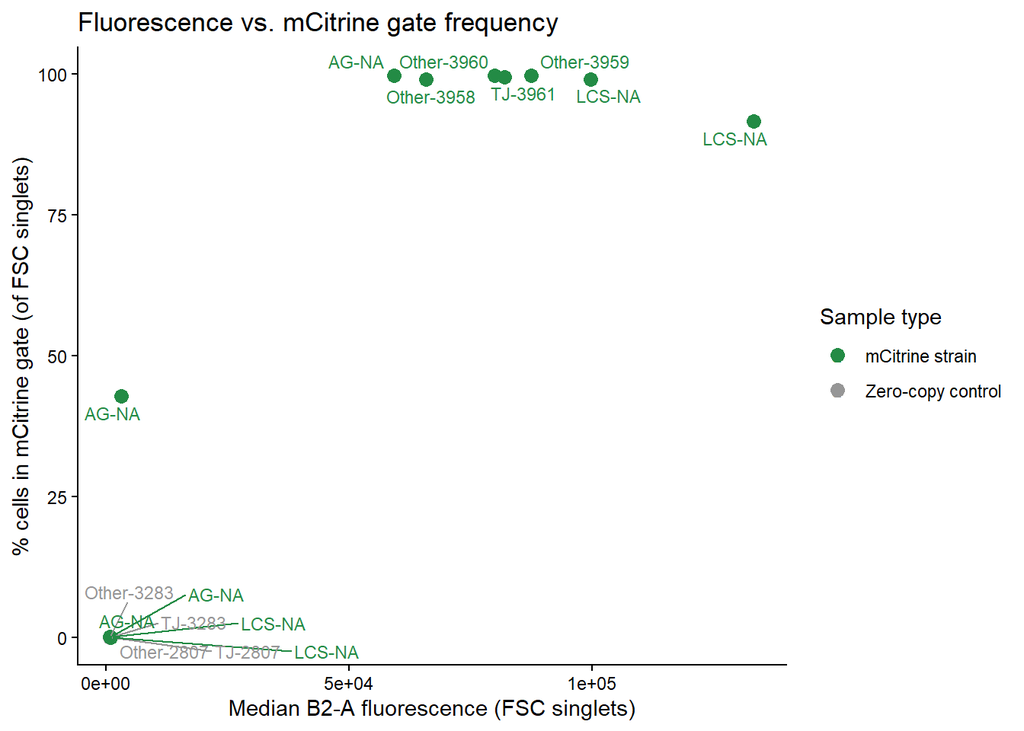

```r
stats_tidy %>%
  mutate(sample_label = paste0(student, "-", strain)) %>%
  ggplot(aes(x = Median_B2A_singlets, y = mCit_pct_parent,
             color = copy_class, label = sample_label)) +
  geom_point(size = 3) +
  ggrepel::geom_text_repel(size = 3, max.overlaps = 15) +
  scale_color_manual(values = c("Zero-copy control" = "#969696", "mCitrine strain" = "#238b45"),
                     name   = "Sample type") +
  xlab("Median B2-A fluorescence (FSC singlets)") +
  ylab("% cells in mCitrine gate (of FSC singlets)") +
  ggtitle("Fluorescence vs. mCitrine gate frequency") +
  theme_classic()
```

> **Note:** `ggrepel` is needed for Plot 4. Install with `install.packages("ggrepel")` if not present.

### Plot 5: Ridge plot of B2-A fluorescence from FCS files (TJ samples)

```r
# Load single-cell distributions if already generated
sc_distr <- read_csv(paste0(version_name, "_SingleCellDistributions.csv"))

sc_distr %>%
  mutate(
    Description = fct_relevel(Description, "0 copy control", "CNV reporter"),
    `mCitrine copy number` = fct_relevel(`mCitrine copy number`, "zero copy", "experimental")
  ) %>%
  ggplot(aes(B2A_FSC, Description, fill = `mCitrine copy number`)) +
  geom_density_ridges(scale = 1) +
  scale_y_discrete(expand = expansion(add = c(0.2, 1.0))) +
  scale_fill_manual(values = RColorBrewer::brewer.pal(3, "Greens")) +
  scale_x_continuous(
    "normalized fluorescence (B2-A / FSC-A)",
    limits = c(0, 3.0),
    breaks = c(0, 1, 2, 3)
  ) +
  theme_classic() +
  theme(
    axis.text.x = element_text(size = 10, color = "black"),
    axis.text.y = element_text(size = 10, color = "black")
  )
```

[output not shown]

## Summary

```r
tj_stats %>%
  select(
    Strain        = strain_label,
    Description,
    `Total singlets`         = Singlets_Count,
    `% zero copy`            = copy0_pct,
    `% one copy`             = copy1_pct,
    `% two+ copy`            = copy2_pct,
    `Median B2-A (singlets)` = Median_B2A_singlets
  ) %>%
  knitr::kable(digits = 2, caption = "TJ sample summary — June 9, 2026")
```

TJ sample summary — June 9, 2026

| Strain | Description | Total singlets | % zero copy | % one copy | % two+ copy | Median B2-A (singlets) |
| --- | --- | --- | --- | --- | --- | --- |
| DGY2807 | 0 copy control | 12694 | 93.74 | 0.00 | 0.00 | 715.86 |
| DGY3961 | CNV reporter | 11670 | 0.18 | 0.11 | 99.43 | 82028.81 |
| DGY3283 | 0 copy control | 10955 | 94.11 | 0.00 | 0.01 | 725.91 |

**Key observations:**

- **DGY2807 and DGY3283** show very low B2-A fluorescence and essentially 0% of cells in the 1-copy or 2-copy gates, confirming their role as **zero-copy (no mCitrine) controls**.
- **DGY3961 and DGY3960** show high B2-A fluorescence, with the majority of cells falling in the **2-copy or higher** gate. This is consistent with mCitrine expression and possible copy number amplification under glutamine-limited growth.
- The overlap between gate classes (especially 1-copy vs 2-copy) reflects the inherent limitation of gating on continuous fluorescence distributions.